# Exploring FordGoBikes Dataset

- 1. Introduction
- 2. Explanatory Data Analysis
- 4. Conclusions

1. Introduction

### Dataset Overview:

FordGoBikes dataset includes a lot of features as it has more than 180,000 records of bikes trips and their information about individual rides made in a bike-sharing system covering the greater San Francisco Bay area in 2017, including stations coordinates, user types, birth year, gender, which can be easly interpret some insights.

### Questions:

- Which age subscribe the service often?
- Which is the Busiest days in the week?
- What is the Peak hours in the day?
- Which Gender using the service the most?
- What is the Average Number of Trips per Day?
- What is the Average Number of Trips per Age?
- Which Shares the bike the most?
- Which are the most used Stations?
- How long Trips take each Day?
- What is Number of Trips and Distance per Age?

2. Explanatory Data Analysis

### Which age subscribe the service often:

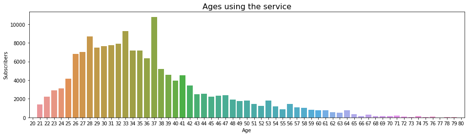

```python
plt.figure(figsize=(16, 4))
subscriber = DF[DF['user_type'] == 'Subscriber']
by_subscriber = subscriber.groupby('Age')[['user_type']].count()
sns.barplot(x=by_subscriber.index, y= by_subscriber["user_type"]);
plt.title('Ages using the service', fontsize=16); plt.xlabel('Age'); plt.ylabel('Subscribers');
```

Most subscribers lie between 26 to 37 years old.

### Which is the Busiest days in the week:

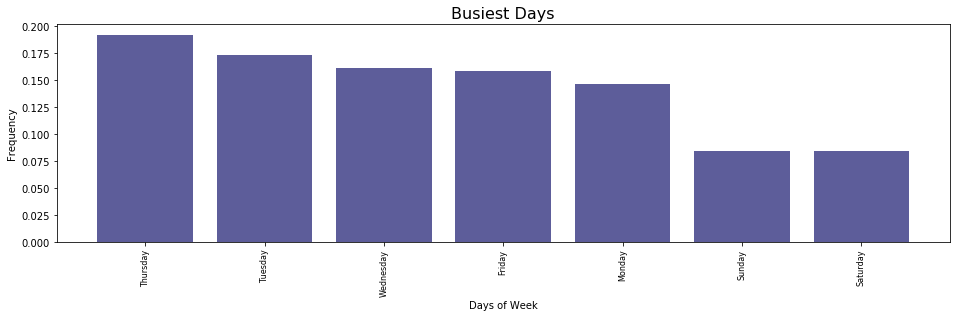

```python
DW = DF['Day_week'].value_counts()/len(DF)
Plot('Busiest Days', 'Days of Week','Frequency', DW.index, DW.values, 'midnightblue', 4)
```

Thursday is the busiest while Saturday as a weekend is the less busy.

### What is the Peak hours in the day:

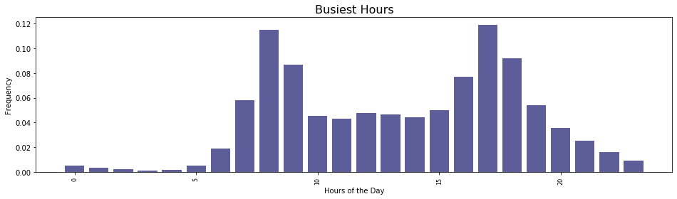

```python
DT = DF['Day_time'].value_counts()/len(DF)
Plot('Busiest Hours', 'Hours of the Day', 'Frequency', DT.index, DT.values, 'midnightblue', 4)
```

Daily peak starts from 8 at morning and begin to decrease from afternoon, and then start to rise again from 3 and reaches the highst point at 5 PM. It's look like we have two peaks at 8AM and 5PM which makes sense, Going to work vs. Leaving.

### Which Gender using the service the most:

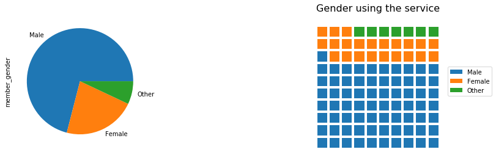

```python
Gender_Count = round(DF['member_gender'].value_counts()/len(DF)*100)
fig, axes = plt.subplots(1, 2,figsize=(16, 4))
Gender_Count.plot(kind='pie', ax=axes[0])

prev_count = 0
for cat in range(Gender_Count.shape[0]):
    blocks = np.arange(prev_count, prev_count + Gender_Count[cat]); x = blocks % 10; y = blocks // 10
    plt.bar(x = x, height = 0.8, width = 0.8, bottom = y); prev_count += Gender_Count[cat]
plt.title('Gender using the service', fontsize=16); plt.xlabel('Gender'); plt.ylabel('Frequency');
plt.legend(Gender_Count.index, bbox_to_anchor = (1, 0.5), loc = 6)
plt.axis('off')
plt.axis('square')
plt.show()
```

Male is a dominant in this job, while about 7% didn't specify.

### What is the Average Number of Trips per Day:

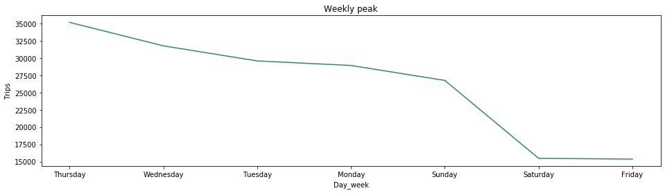

```python
# ploting the column DF[Day_week] frequency
by_day = DF.groupby('Day_week').count()
fig, axes = plt.subplots(1, 1,figsize=(16, 4))
plt.xlabel('Day_week')
plt.ylabel('Trips')
plt.title('Weekly peak')
plt.plot(DF['Day_week'].unique().tolist(), DF['Day_week'].value_counts().values, c='seagreen');
```

### What is the Average Number of Trips per Age:

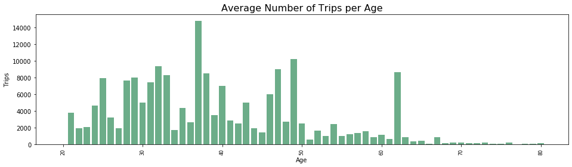

```python
Plot('Average Number of Trips per Age', 'Age', 'Trips', DF['Age'].unique()[:80].tolist(), DF['Age'].value_counts(), 'seagreen');
```

Most of the users are between ages 20-50 with an average of 37 is where the most of the users arround.

### Which Shares the bike the most:

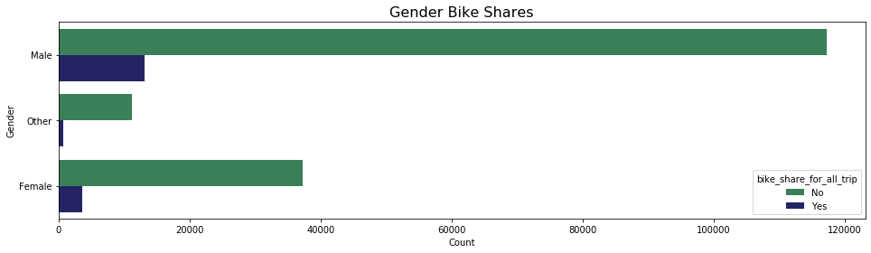

```python
# Bike_share for gender
plt.figure(figsize=(16, 4))
sns.countplot(y=DF['member_gender'], hue = DF['bike_share_for_all_trip'], color='seagreen', palette=['seagreen','midnightblue']);
plt.title('Gender Bike Shares', fontsize=16); plt.xlabel('Count'); plt.ylabel('Gender');
```

### Which are the most used Stations:

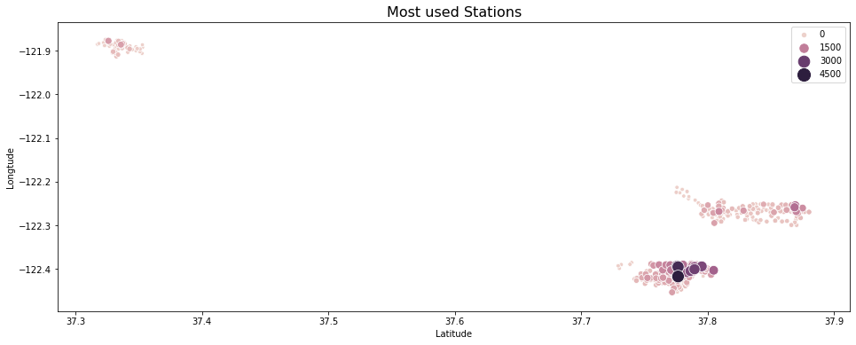

```python
Data = DF.groupby(['start_station_latitude', 'start_station_longitude']).count().sort_values('Age')
x = np.array(Data.index.values.tolist())[:,0]
y = np.array(Data.index.values.tolist())[:,1]
h = np.array(Data.Age.values.tolist())
plt.figure(figsize=(16, 6))
sns.scatterplot(x=x, y=y, hue=h, size=h, sizes=(20, 200))
plt.title('Most used Stations', fontsize=16); plt.xlabel('Latitude'); plt.ylabel('Longtude');
plt.show()
```

There are three spots which rides happens frequently with most frequency in the bottom spot.